# HW1

Jake VanCampen

Oct-18-2017

## Exploratory Data Analysis

An RNA-Seq dataset from two populations of threespine stickleback fish `HW_RNAseq.csv` were read it into R.

```r
# load tidyverse packages
library(tidyverse)

RNAseq_raw <- read_csv('HW_RNAseq.csv',col_names = TRUE)
```

To determing how the data were read in by the `{readr} read.csv()` function, the class of the dataset was observed with the `class()` funtion. Then, an initial look at the data.

```r
class(RNAseq_raw)
```

```
## [1] "tbl_df"     "tbl"        "data.frame"
```

```r
head(RNAseq_raw)
```

```
## # A tibble: 6 x 14
##   SampleID Population    Treatment    Sex   Gene01   Gene02   Gene03
##      <chr>      <chr>        <chr>  <chr>    <dbl>    <dbl>    <dbl>
## 1    BtCV1       Boot Conventional   male 356.7014 203.0008 412.7683
## 2    BtCV2       Boot Conventional   male 348.7677 297.5724 385.0310
## 3    BtCV3       Boot Conventional female 361.2610 296.8256 388.7253
## 4    BtCV4       Boot Conventional female 448.2658 213.5716 332.0922
## 5    BtCV5       Boot Conventional   male 470.6721 227.1835 336.9708
## 6    BTMA1       Boot    MonoAssoc   male 257.8895 367.5888 422.4385
## # ... with 7 more variables: Gene04 <dbl>, Gene05 <dbl>, Gene06 <dbl>,
## #   Gene07 <dbl>, Gene08 <dbl>, Gene09 <dbl>, Gene10 <dbl>
```

It looks like the data were read in as a tibble. That’s good news, it will make the dataset easier to work with. The categorical variables seem to be listed first, followed by the response variables. It could be useful to generate a list of each.

```r
vars_categorical <- colnames(RNAseq_raw)[1:4]
vars_categorical
```

```
## [1] "SampleID"   "Population" "Treatment"  "Sex"
```

```r
vars_response <- colnames(RNAseq_raw)[5:length(colnames(RNAseq_raw))]
vars_response
```

```
##  [1] "Gene01" "Gene02" "Gene03" "Gene04" "Gene05" "Gene06" "Gene07"
##  [8] "Gene08" "Gene09" "Gene10"
```

### Tidy Data

It looks like there are 10 continuous variables (genes) that are described by these data. Before we can make histograms for each gene the data will need to be tidied such that each row is an observation and each column is a variable. Right now there are too many columns representing the same variable. To achieve this, the `tidyr` function `gather()` can be used to manipulate the data.frame to merge the gene variables.

```r
# load tidyr package
library(tidyr)

data_tidy <- gather(RNAseq_raw, gene, count, -SampleID, -Population, -Treatment, -Sex)

head(data_tidy)
```

```
## # A tibble: 6 x 6
##   SampleID Population    Treatment    Sex   gene    count
##      <chr>      <chr>        <chr>  <chr>  <chr>    <dbl>
## 1    BtCV1       Boot Conventional   male Gene01 356.7014
## 2    BtCV2       Boot Conventional   male Gene01 348.7677
## 3    BtCV3       Boot Conventional female Gene01 361.2610
## 4    BtCV4       Boot Conventional female Gene01 448.2658
## 5    BtCV5       Boot Conventional   male Gene01 470.6721
## 6    BTMA1       Boot    MonoAssoc   male Gene01 257.8895
```

Okay that looks better, now ‘gene’ is a categorical variable, and the associated ‘counts’ were still retained. This will make it easier to visualize the data.

### Histograms

To visualize the gene counts, histograms can be made to show the distribution of counts for each gene using `ggplot`.

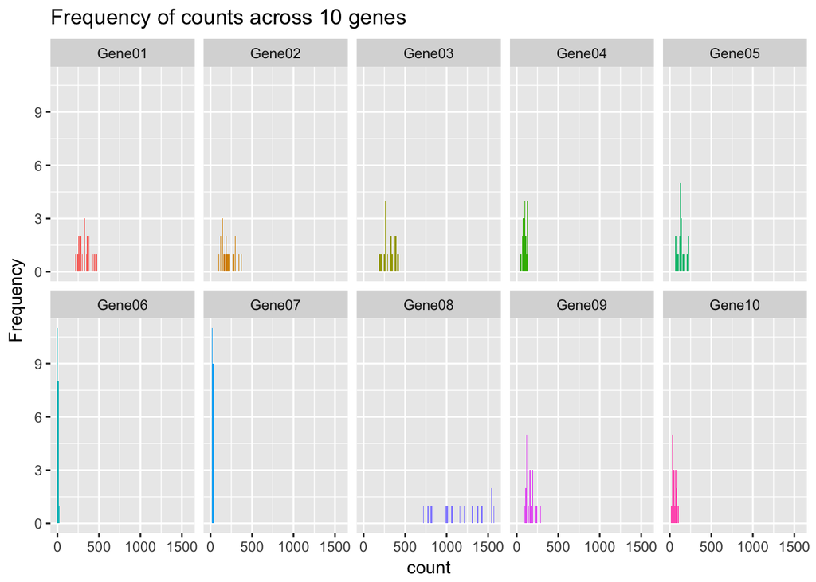

```r
ggplot(data = data_tidy, mapping = aes(x = count, fill = gene))+
  geom_histogram(binwidth = 10)+
  facet_wrap(~gene, nrow = 2)+
  theme(legend.position = "none")+
  ggtitle('Frequency of counts across 10 genes')+
  ylab('Frequency')
```

To perform z-transformation on the data, they can be mean centered and scaled using the `scale()` function. Histograms of the z-transformed counts for just two genes are plotted here.

```r
# Ceci n'est pas une pipe
library(magrittr)

ztrans <- data_tidy %>%
  group_by(gene) %>%
  do(mutate(., z_trans = scale(.$count,
                               center = TRUE,
                               scale = TRUE)))

head(ztrans)
```

```
## # A tibble: 6 x 7
## # Groups:   gene [1]
##   SampleID Population    Treatment    Sex   gene    count    z_trans
##      <chr>      <chr>        <chr>  <chr>  <chr>    <dbl>      <dbl>
## 1    BtCV1       Boot Conventional   male Gene01 356.7014  0.4349682
## 2    BtCV2       Boot Conventional   male Gene01 348.7677  0.3232728
## 3    BtCV3       Boot Conventional female Gene01 361.2610  0.4991615
## 4    BtCV4       Boot Conventional female Gene01 448.2658  1.7240712
## 5    BtCV5       Boot Conventional   male Gene01 470.6721  2.0395225
## 6    BTMA1       Boot    MonoAssoc   male Gene01 257.8895 -0.9561690
```

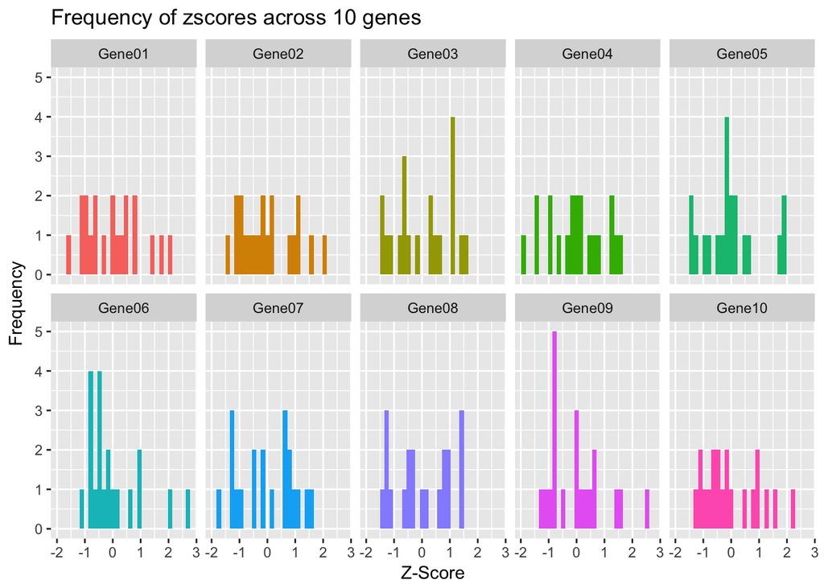

```r
# plot all genes
ztrans %>%
  ggplot(., aes(z_trans, fill = gene))+
    geom_histogram()+
    facet_wrap('gene', nrow = 2)+
    theme(legend.position = "none")+
    ggtitle('Frequency of zscores across 10 genes')+
    xlab('Z-Score')+
    ylab('Frequency')
```

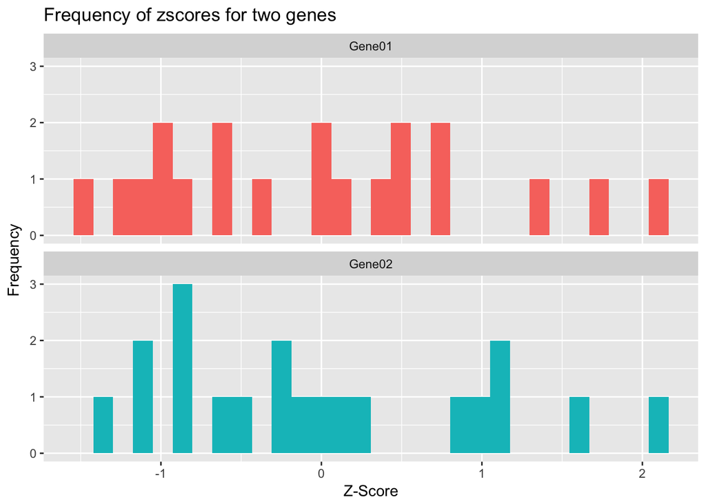

```r
# plot only two genes
ztrans %>%
  filter(gene == 'Gene01' | gene == 'Gene02') %>%
  ggplot(., aes(z_trans, fill = gene))+
    geom_histogram()+
    facet_wrap('gene', nrow = 2)+
    theme(legend.position = "none")+
    ggtitle('Frequency of zscores for two genes')+
    xlab('Z-Score')+
    ylab('Frequency')
```

Very nice. Centering and scaling the data make it a lot easier to see the differences between counts faceted by gene.

### Boxplots

It would also be interesting to see how these counts data are distributed with respect to other categorical variables. Let’s visuallize this with box plots for the original data, as well as the Z-transformed data.

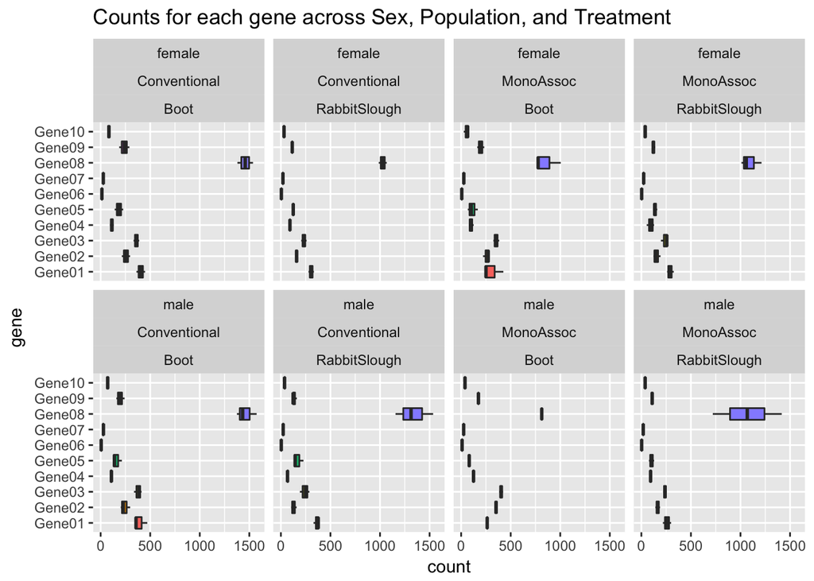

```r
ggplot(data_tidy, aes(gene, count, fill = gene))+
  geom_boxplot()+
  facet_wrap(c('Sex', 'Treatment', 'Population'), nrow = 2)+
  theme(legend.position = "none")+
  ggtitle('Counts for each gene across Sex, Population, and Treatment')+
  coord_flip()
```

So much information in one figure! Let’s take a look at the Z-transformed counts in this same fashion.

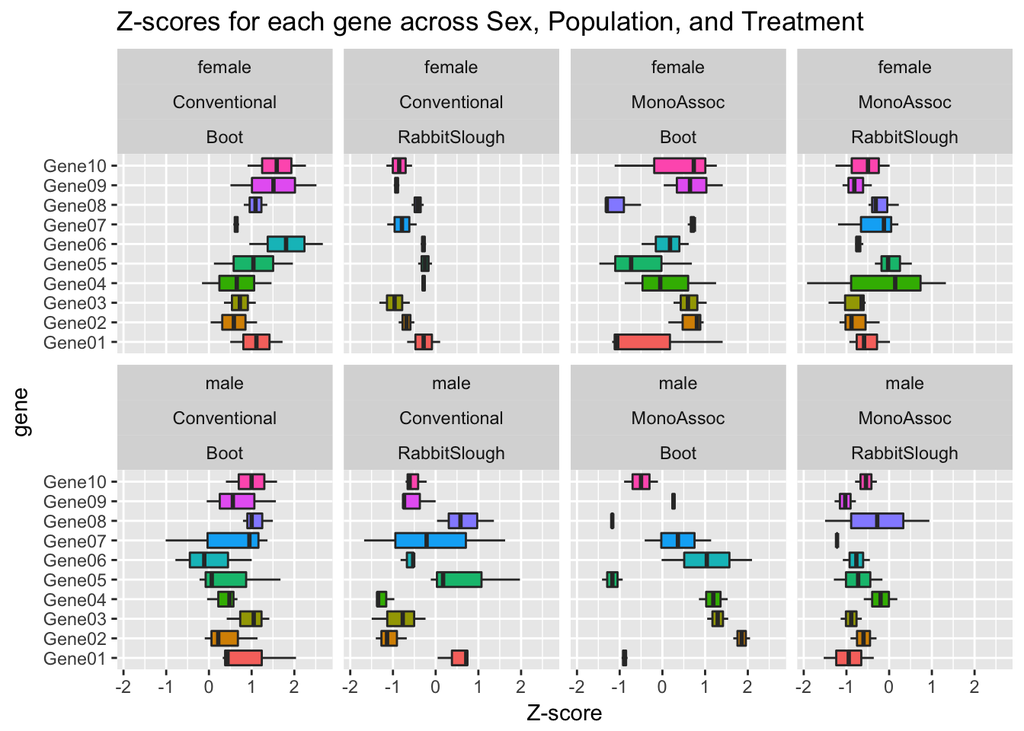

```r
ggplot(ztrans, aes(gene, z_trans, fill = gene))+
  geom_boxplot()+
  facet_wrap(c('Sex', 'Treatment', 'Population'), nrow = 2)+
  theme(legend.position = "none")+
  ggtitle('Z-scores for each gene across Sex, Population, and Treatment')+
  ylab('Z-score')+
  coord_flip()
```

It’s much easier to see the differences between data groupped by categorical variables when the data have been Z-transformed.

### Summary Table

let’s generate a table of summary statistics for each Population, Sex, and Treatment, at all the gene levels.

```r
library(pander)

summary_sex <- data_tidy %>%
  group_by(gene,Sex) %>%
  summarise_at(., 'count', .funs = c(sex_mean = 'mean', sex_Var = 'var', sex_sd = 'sd'))

summary_pop <- data_tidy %>%
  group_by(gene,Population) %>%
  summarise_at(., 'count', .funs = c(Pop_mean = 'mean', Pop_Var = 'var', Pop_sd = 'sd'))

summary_trt <- data_tidy %>%
  group_by(gene,Treatment) %>%
  summarise_at(., 'count', .funs = c(trt_mean = 'mean', trt_Var = 'var', trt_sd = 'sd'))

summary_by_fctr <- cbind(summary_sex,summary_pop,summary_trt) %>%
  .[,-c(6,11)]

pander(summary_by_fctr)
```

Table continues below

| gene | Sex | sex_mean | sex_Var | sex_sd | Population | Pop_mean |
| --- | --- | --- | --- | --- | --- | --- |
| Gene01 | female | 321.1 | 5238 | 72.37 | Boot | 343 |
| Gene01 | male | 330.5 | 5364 | 73.24 | RabbitSlough | 308.6 |
| Gene02 | female | 206.3 | 3924 | 62.64 | Boot | 272.1 |
| Gene02 | male | 214.7 | 8404 | 91.67 | RabbitSlough | 148.9 |
| Gene03 | female | 296.3 | 4824 | 69.46 | Boot | 372.3 |
| Gene03 | male | 314.4 | 7180 | 84.74 | RabbitSlough | 238.4 |
| Gene04 | female | 99.15 | 595.1 | 24.4 | Boot | 109.5 |
| Gene04 | male | 96.33 | 515.2 | 22.7 | RabbitSlough | 85.98 |
| Gene05 | female | 137.2 | 1840 | 42.89 | Boot | 134.9 |
| Gene05 | male | 135 | 2737 | 52.31 | RabbitSlough | 137.3 |
| Gene06 | female | 6.295 | 15.98 | 3.998 | Boot | 8.133 |
| Gene06 | male | 5.391 | 13.25 | 3.64 | RabbitSlough | 3.553 |
| Gene07 | female | 24.23 | 10.78 | 3.284 | Boot | 26.26 |
| Gene07 | male | 23.65 | 28.41 | 5.331 | RabbitSlough | 21.62 |
| Gene08 | female | 1080 | 58343 | 241.5 | Boot | 1147 |
| Gene08 | male | 1215 | 102841 | 320.7 | RabbitSlough | 1148 |
| Gene09 | female | 166.2 | 3658 | 60.48 | Boot | 200.6 |
| Gene09 | male | 156.3 | 1797 | 42.4 | RabbitSlough | 121.8 |
| Gene10 | female | 50.95 | 629.3 | 25.09 | Boot | 62.38 |
| Gene10 | male | 48.35 | 300.1 | 17.32 | RabbitSlough | 36.91 |

| Pop_Var | Pop_sd | Treatment | trt_mean | trt_Var | trt_sd |
| --- | --- | --- | --- | --- | --- |
| 7378 | 85.89 | Conventional | 368.3 | 3168 | 56.28 |
| 2614 | 51.12 | MonoAssoc | 283.3 | 3464 | 58.86 |
| 3069 | 55.4 | Conventional | 194 | 4478 | 66.92 |
| 861.5 | 29.35 | MonoAssoc | 227 | 7284 | 85.34 |
| 1160 | 34.05 | Conventional | 304.6 | 6154 | 78.45 |
| 1060 | 32.56 | MonoAssoc | 306.1 | 6030 | 77.65 |
| 332.6 | 18.24 | Conventional | 93.48 | 431.4 | 20.77 |
| 474.7 | 21.79 | MonoAssoc | 102 | 642.9 | 25.36 |
| 3081 | 55.51 | Conventional | 160 | 1978 | 44.47 |
| 1494 | 38.66 | MonoAssoc | 112.2 | 1327 | 36.43 |
| 17.12 | 4.138 | Conventional | 6.327 | 16.96 | 4.118 |
| 0.9075 | 0.9526 | MonoAssoc | 5.36 | 12.2 | 3.493 |
| 9.643 | 3.105 | Conventional | 24.26 | 23.95 | 4.894 |
| 17.74 | 4.212 | MonoAssoc | 23.62 | 15.2 | 3.898 |
| 116159 | 340.8 | Conventional | 1336 | 41755 | 204.3 |
| 55112 | 234.8 | MonoAssoc | 959.3 | 50721 | 225.2 |
| 1735 | 41.65 | Conventional | 170.2 | 3445 | 58.7 |
| 330.2 | 18.17 | MonoAssoc | 152.2 | 1886 | 43.42 |
| 502.9 | 22.43 | Conventional | 55.82 | 558.2 | 23.63 |
| 69.87 | 8.359 | MonoAssoc | 43.47 | 290.3 | 17.04 |

## Standard Error and Confidence interval

Here, the standard error and 95% confidence interval are calculated using the parametic, as well as bootstrap resampling approach. The results are compared in a table.

```r
library(knitr)

# parametric approach to standard error
SE_para <- function(x) {
  l_CI <- mean(x) - (sd(x)/sqrt(length(x)) * qt(0.975, (length(x)-1)))
  u_CI <- mean(x) + (sd(x)/sqrt(length(x)) * qt(0.975, (length(x)-1)))

  return(data.frame(mean = mean(x),
                    SE = sd(x)/sqrt(length(x)),
                    p.ci.lower = l_CI,
                    p.ci.upper = u_CI))
}


# Bootstrapped standard error of the mean
SEM_boot <- function(x) {
z <- NULL
for (i in 1:1000) {
  xboot <- sample(x, 20, replace = T)
  z[i] <- mean(xboot)
}
SEM <- sd(z)
CI <- quantile(z,c(0.025,0.975))
return(data.frame('SEM_bootstr' = SEM,
                  bm.lower.ci = CI[1],
                  bm.upper.ci = CI[2]))
}

# Bootstrapped standard error of the variance
SEV_boot <- function(x) {
z <- NULL
for (i in 1:1000) {
  xboot <- sample(x, 20, replace = T)
  z[i] <- var(xboot)
}
SEV <- sd(z)
CI <- quantile(z,c(0.025,0.975))
return(data.frame('SEV_bootstr' = SEV,
                  bv.lower.ci = CI[1],
                  bv.upper.ci = CI[2]))
}


data_tidy %>%
  group_by(gene) %>%
  do(data.frame(
    SE_para(.$count),
    SEM_boot(.$count),
    SEV_boot(.$count))
    ) %>% kable(.,digits = 2,
                align = 'c',
                caption = 'Comparison of parametric and bootstrap resampling approaches to standard error')
```

Comparison of parametric and bootstrap resampling approaches to standard error

| gene | mean | SE | p.ci.lower | p.ci.upper | SEM_bootstr | bm.lower.ci | bm.upper.ci | SEV_bootstr | bv.lower.ci | bv.upper.ci |
| --- | --- | --- | --- | --- | --- | --- | --- | --- | --- | --- |
| Gene01 | 325.81 | 15.88 | 292.56 | 359.05 | 15.54 | 295.31 | 356.60 | 1250.74 | 2591.97 | 7343.17 |
| Gene02 | 210.50 | 17.11 | 174.68 | 246.32 | 17.59 | 174.89 | 243.07 | 1434.10 | 2748.68 | 8311.48 |
| Gene03 | 305.33 | 16.99 | 269.77 | 340.89 | 16.21 | 272.87 | 336.21 | 1063.93 | 3561.04 | 7590.54 |
| Gene04 | 97.74 | 5.14 | 86.99 | 108.50 | 5.17 | 87.64 | 107.90 | 125.81 | 273.81 | 763.36 |
| Gene05 | 136.10 | 10.41 | 114.30 | 157.89 | 10.17 | 117.29 | 157.18 | 654.77 | 807.94 | 3389.99 |
| Gene06 | 5.84 | 0.84 | 4.09 | 7.60 | 0.82 | 4.36 | 7.58 | 5.49 | 3.48 | 25.09 |
| Gene07 | 23.94 | 0.97 | 21.92 | 25.96 | 0.94 | 22.05 | 25.81 | 3.55 | 11.25 | 24.61 |
| Gene08 | 1147.65 | 63.69 | 1014.35 | 1280.95 | 60.62 | 1030.72 | 1257.37 | 15366.89 | 47541.22 | 109063.43 |
| Gene09 | 161.22 | 11.42 | 137.31 | 185.13 | 11.02 | 141.68 | 184.98 | 837.77 | 1043.16 | 4215.64 |
| Gene10 | 49.65 | 4.70 | 39.81 | 59.49 | 4.50 | 41.11 | 58.56 | 123.74 | 195.27 | 675.03 |

## Douglas Fir at Mt. Pisgah

Plot `Plots with X trees` vs. `Number of Trees in a Plot`, and determine how they are distributed.

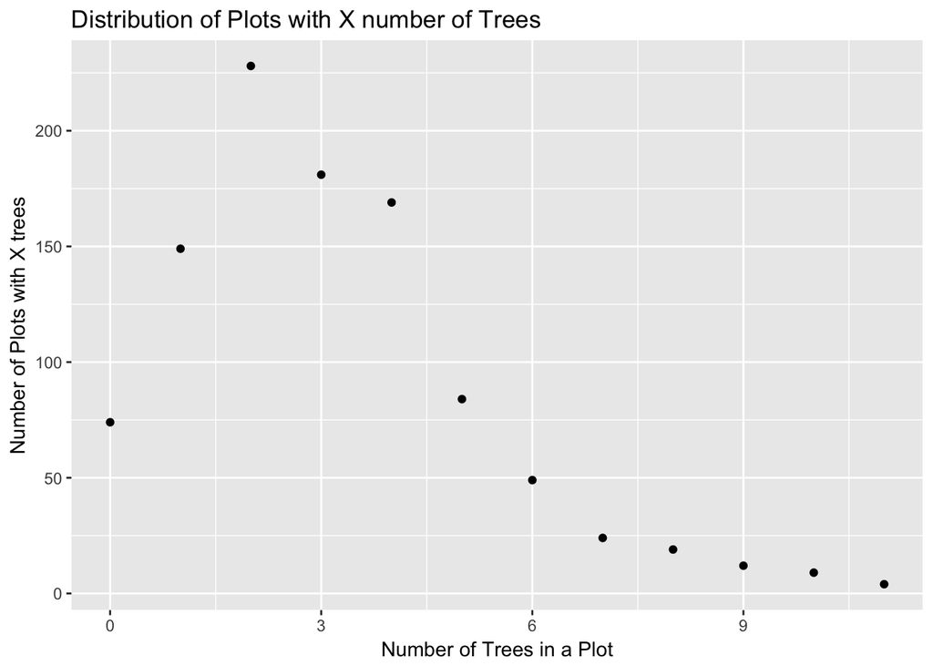

```r
trees <- tbl_df(data.frame('num_trees' = c(0:11), 'num_plots' = c(74,149,228,181,169,84,49,24,19,12,9,4)))

ggplot(trees, aes(num_trees, num_plots))+
  geom_point()+
  xlab('Number of Trees in a Plot')+
  ylab('Number of Plots with X trees')+
  ggtitle('Distribution of Plots with X number of Trees')+
  theme_gray()
```

These data look to be Poisson distributed! We can calculate the mean number of trees per plot and the variance in the number of trees per plot, which should approach the same number if the data are really Poisson distributed.

```r
# determine the total number of trees by unpacking these data
total_trees <- rep(trees$num_trees, trees$num_plots)

# calculate the mean and variance
mean(total_trees)
```

```
## [1] 3.093812
```

```r
var(total_trees)
```

```
## [1] 4.410771
```

It appears we need more support to test that these data are Poisson distributed, because the calculated mean and variance (of this small dataset) are unequal. Here, a maximum likelihood appraoch is used to estimate the parameter lambda using the poisson equaiton:
$$P\left( x \right) = \frac{{e^{ - \lambda } \lambda ^x }}{{x!}}$$

The 95% confidence interval of estimating this parameter is also calculated, and may tell how acceptable it is that the mean and variance are different.

```r
x <- seq(0,11,length.out = 12)
y <- dpois(trees$num_trees, mean(total_trees), log = T)

# log likelihood function
log_like <- data.frame("x" = x, "ln_y" = y)

# maximum likelihood estimate
subset(log_like, ln_y == max(ln_y))
```

```
##   x     ln_y
## 4 3 -1.49736
```

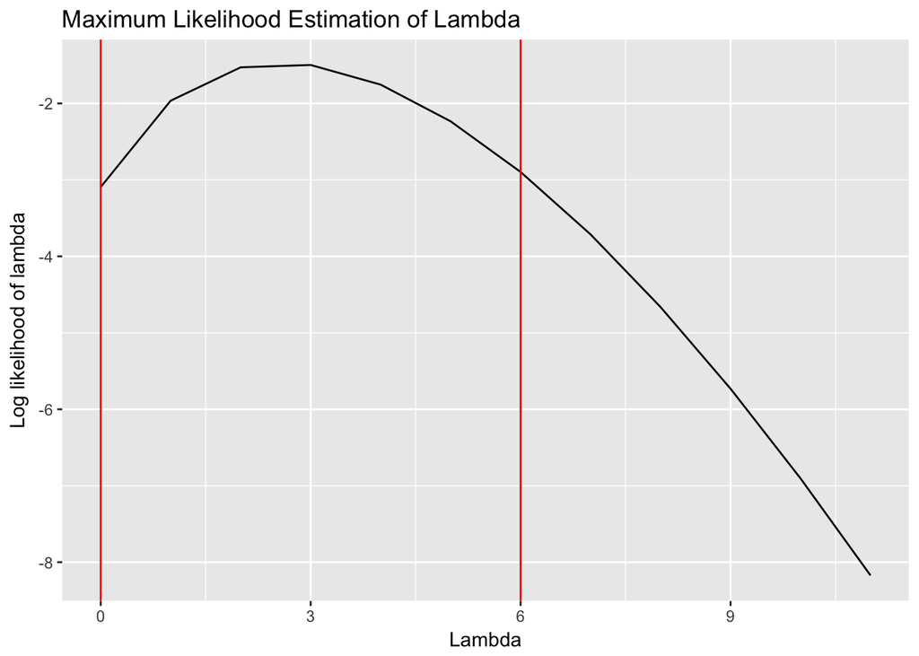

```r
# confidence interval
CI <- subset(log_like, ln_y>=max(ln_y)-1.92)

ggplot(log_like, aes(x, ln_y))+
  geom_line()+
  geom_vline(xintercept = c(min(CI$x), max(CI$x)), color = 'red') +
  xlab('Lambda')+
  ylab('Log likelihood of lambda')+
  ggtitle('Maximum Likelihood Estimation of Lambda')
```